# Comparison of daily temperature variability trends from various stations distributed globally

Global climate change is causing uneven warming patterns that have a significant impact on how ecosystems exchange water and carbon. An important starting point for understanding this phenomenon is the daily temperature range (DTR), which measures the difference between day and night temperatures.

Whereas Kar et al. (1993) indicate a predominantly negative trend in DTR, more recent publications show a shift in the trend from predominantly negative to positive (Zhong et al. 2023, Liu et al. 2024). The shift from negative to positive is said to have taken place in the late 1980s and early 1990s.

using global distributed measuring stations, we want to investigate how much the trend in DTR differs between stations and whether there is a general positive or negative trend. Further, we want to compare the observed trends with the ones from recent publications.

```python
# import packages
import pandas as pd
import numpy as np
import holoviews as hv
import hvplot.pandas
import seaborn as sns
from sklearn.linear_model import LinearRegression

import matplotlib.pyplot as plt
import folium
import cartopy.crs as ccrs
import cartopy.feature as cfeature
```

## Climate Data

Climate Data were taken from Meteorological data was taken from [Global Historical Climatology Network daily (GHCNd)](https://www.ncei.noaa.gov/products/land-based-station/global-historical-climatology-network-daily#:~:text=The%20Global%20Historical%20Climatology%20Network,suite%20of%20quality%20assurance%20reviews.). This database contains observations of one or more of over 40 meteorological elements at morre and 90,000 stations worldwide. For this analysis, we choose the daily maximum and minimum temperature at ten station. These stations were selected because they are relatively evenly distributed across the globe, from the high latitudes of both hemispheres to the tropics.

The periods of available observation vary greatly from station to station. It should also be noted that two data sets were selected for Cape Grim, as one data set contains a significant gap and the second covers a very short period of time.

[output not shown]

```python
# URLs to the datasets
# TMAX, TMIN, and TAVG were grapped
# TMAX and TMIN are used

svalbard_ncei_url = ('https://www.ncei.noaa.gov/access/services/data/v1'
                    '?dataset=daily-summaries&dataTypes=TMAX,TMIN,TAVG&'
                    'stations=SV000001008&startDate=1975-08-01&'
                    'endDate=2025-10-31&units=standard')

barrow_ncei_url = ('https://www.ncei.noaa.gov/access/services/data/v1'
                   '?dataset=daily-summaries&dataTypes=TMAX,TMIN,TAVG&'
                   'stations=USW00027502&startDate=1901-09-01&'
                   'endDate=2025-11-27&units=standard')

ushuaia_ncei_url = ('https://www.ncei.noaa.gov/access/services/data/v1'
                    '?dataset=daily-summaries&dataTypes=TMAX,TMIN,TAVG&'
                    'stations=ARM00087938&startDate=1957-06-30&'
                    'endDate=2025-08-24&units=standard')

cape_grim_1_ncei_url = ('https://www.ncei.noaa.gov/access/services/data/v1'
                        '?dataset=daily-summaries&dataTypes=TMAX,TMIN,TAVG&'
                        'stations=ASN00097000&startDate=1901-01-01&'
                        'endDate=2025-11-21&units=standard')

cape_grim_2_ncei_url = ('https://www.ncei.noaa.gov/access/services/data/v1'
                        '?dataset=daily-summaries&dataTypes=TMAX,TMIN,TAVG&'
                        'stations=ASN00091245&startDate=1985-08-08&'
                        'endDate=2023-03-29&units=standard')

praia_ncei_url = ('https://www.ncei.noaa.gov/access/services/data/v1'
                    '?dataset=daily-summaries&dataTypes=TMAX,TMIN,TAVG&'
                    'stations=CVM00008589&startDate=1973-01-01&'
                    'endDate=2025-08-24&units=standard')

mendoza_ncei_url = ('https://www.ncei.noaa.gov/access/services/data/v1'
                    '?dataset=daily-summaries&dataTypes=TMAX,TMIN,TAVG&'
                    'stations=AR000087418&startDate=1957-06-30&'
                    'endDate=2025-08-24&units=standard')

saltlakecity_ncei_url = ('https://www.ncei.noaa.gov/access/services/data/v1'
                         '?dataset=daily-summaries&dataTypes=TMAX,TMIN,TAVG&'
                         'stations=USW00024127&startDate=1941-11-01&'
                         'endDate=2025-11-27&units=standard')

kl_feldberg_ncei_url = ('https://www.ncei.noaa.gov/access/services/data/v1'
                    '?dataset=daily-summaries&dataTypes=TMAX,TMIN,TAVG&'
                    'stations=GME00124546&startDate=1936-01-01&'
                    'endDate=2025-08-24&units=standard')

kathmandu_ncei_url = ('https://www.ncei.noaa.gov/access/services/data/v1'
                    '?dataset=daily-summaries&dataTypes=TMAX,TMIN,TAVG&'
                    'stations=NP000444540&startDate=1971-01-01&'
                    'endDate=2025-08-24&units=standard')

# put the urls into a list for better looping
url_list = [svalbard_ncei_url,
            barrow_ncei_url,
            ushuaia_ncei_url,
            cape_grim_1_ncei_url,
            cape_grim_2_ncei_url,
            praia_ncei_url,
            mendoza_ncei_url,
            saltlakecity_ncei_url,
            kl_feldberg_ncei_url,
            kathmandu_ncei_url]

# list of same length and order as url_list
places_list = ["svalbard",
               "barrow",
               "ushuaia",
               "cape_grim_1",
               "cape_grim_2",
               "praia",
               "mendoza",
               "salt_lake_city",
               "kleiner_feldberg",
               "kathmandu"]

# latitudes and longitudes of the stations, needed for the first overview plot
places_lat = [78.25, 71.28703, -54.843, -42.1986, -40.6828, 14.917, -32.833, 40.77069, 50.2219, 27.7]
places_lon = [15.4667, -156.73938, -68.296, 145.17, 144.69, -23.6,-68.783, -111.96503, 8.4447,85.367]

# color for every station for plotting later
places_colors = ["black",
                 "red",
                 "green",
                 "blue",
                 "purple",
                 "orange",
                 "grey",
                 "coral",
                 "cyan",
                 "lime"]
```

## Functions

Here, several functions are defined that will be used at a later point in time.

```python
def Fahrenheit_to_Celcius(temperature_F: float):
    """Convert Fahrenheit temperature to Celcius
    :param temperature_F (float): Temperature in Fahrenheit
    """
    return (temperature_F-32) * 5/9


def get_trend_line(column_name: str,
                   df : pd.DataFrame):
    """calcuate linear regression line
    :param station_name: strinf station name
    :param df: input DataFrame
    """

    tmp_df = df[[column_name]].copy()

    # Index to time "number" column
    tmp_df["TIME"] = np.arange(len(tmp_df.index))

    # Drop rows with any NaN value
    tmp_df_cleaned = tmp_df.dropna()

    # Fit data
    X = tmp_df_cleaned.loc[:, ['TIME']]
    y = tmp_df_cleaned.loc[:, column_name]

    # model temperatrure difference
    model = LinearRegression()
    model.fit(X, y)

    # calculate/predict trend line from LinearRegression model
    y_pred = pd.Series(model.predict(X), index=X.index)

    return model, y_pred


def get_season(month):
    """
    get season by month
    """
    if 3 <= month <= 5:
        return 'MAM'
    elif 6 <= month <= 8:
        return 'JJA'
    elif 9 <= month <= 11:
        return 'SON'
    else:
        return 'DJF'
```

### Graphical representation of station locations

Plot stations on a map The chosen station are distributed globally.

```python
# Define a location (latitude, longitude)
coordinates = [0,0]  # center map

# Create a Folium map centered at the coordinates
my_map = folium.Map(location=coordinates, zoom_start=2)

for lat, lon, name in zip(places_lat, places_lon, places_list):
    # Add a marker at the specified coordinates
    folium.Marker([lat, lon], popup=name).add_to(my_map)

# Save the map to an HTML file or display it directly in a Jupyter Notebook
my_map.save("station_overview.html")
my_map
```

Make this Notebook Trusted to load map: File -> Trust Notebook

[interactive chart not shown]

### Download station data

Download the stations temperature date. Daily minimum, maximum and average temperaturwe (if available) are downloaded.

```python
# save the data in a dictionare form first
station_dic = {}

for url, name in zip(url_list, places_list):
    # Download the climate data from url
    tmp_df = pd.read_csv(
        url,
        index_col='DATE',
        parse_dates=True,
        na_values=['NaN']
    )
    # add column in uni Celcius
    tmp_df['{}_MAX_TEMP_C'.format(name)]  = tmp_df['TMAX'].apply(Fahrenheit_to_Celcius)
    tmp_df['{}_MIN_TEMP_C'.format(name)]  = tmp_df['TMIN'].apply(Fahrenheit_to_Celcius)
    tmp_df['{}_AVG_TEMP_C'.format(name)]  = tmp_df['TAVG'].apply(Fahrenheit_to_Celcius)
    tmp_df['{}_DIFF_C'.format(name)]  = (tmp_df['{}_MAX_TEMP_C'.format(name)] - tmp_df['{}_MIN_TEMP_C'.format(name)]).abs()

    # drop the original columns with units in Fahrenheit
    tmp_df.drop(['TMAX', 'TMIN', 'TAVG', 'STATION'], axis=1, inplace=True)
    station_dic[name] = tmp_df
```

### Merge the DataFrames

merge the data to one DataFrame for easier data handling. "outer" is used to not loose data when merging.

```python
# Start a new merged DataFrame with the first stations
stations_merged = station_dic['svalbard']

# Merge subsequent DataFames
stations_merged = pd.merge(stations_merged, station_dic['barrow'], how='outer', left_index=True, right_index=True)
stations_merged = pd.merge(stations_merged, station_dic['ushuaia'], how='outer', left_index=True, right_index=True)
stations_merged = pd.merge(stations_merged, station_dic['cape_grim_1'], how='outer', left_index=True, right_index=True)
stations_merged = pd.merge(stations_merged, station_dic['cape_grim_2'], how='outer', left_index=True, right_index=True)
stations_merged = pd.merge(stations_merged, station_dic['praia'], how='outer', left_index=True, right_index=True)
stations_merged = pd.merge(stations_merged, station_dic['mendoza'], how='outer', left_index=True, right_index=True)
stations_merged = pd.merge(stations_merged, station_dic['salt_lake_city'], how='outer', left_index=True, right_index=True)
stations_merged = pd.merge(stations_merged, station_dic['kleiner_feldberg'], how='outer', left_index=True, right_index=True)
stations_merged = pd.merge(stations_merged, station_dic['kathmandu'], how='outer', left_index=True, right_index=True)
stations_merged['Year'] = stations_merged.index.year
```

Adding columns for years, month, and season. They will be used in the next step to group the DataFrame.

```python
# generate iindependent copy
stations_merged_season = stations_merged.copy()

stations_merged_season['Year'] = stations_merged_season.index.year
stations_merged_season['Month'] = stations_merged_season.index.month
stations_merged_season['Season'] = stations_merged_season['Month'].apply(get_season)
```

```python
# Group DataFrame by Year and Season
stations_merged_grouped = stations_merged_season.groupby(['Year', 'Season']).mean().reset_index()
```

For plotting the data, we would like to have a datetime index, like before in the merged data. We take the middle month of the respective season and the year to create timestamps. These are set as the new index.

```python
season_to_month = {
    'MAM': 4,
    'JJA': 7,
    'SON': 10,
    'DJF': 1
}

# series of combined year and month
year_month = (
    stations_merged_grouped['Year'].astype(str) +
    stations_merged_grouped['Season'].map(season_to_month).astype(str)
)

# set new index - using pd.to_datetime method from pandas
stations_merged_grouped.index = pd.to_datetime(year_month, format='%Y%m')
```

### Plot the stations separatly with trends by season.

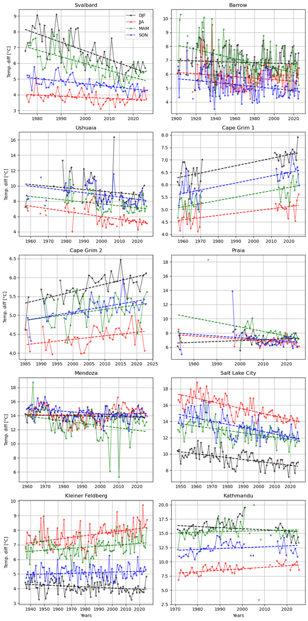

```python
fig, ax = plt.subplots(5, 2, figsize=(10, 20))

# Seasonal colors
season_colors = {
    'DJF': 'black',
    'JJA': 'red',
    'MAM': 'green',
    'SON': 'blue'
}

# Stations in the same order as subplots
stations = [
    ('svalbard_DIFF_C', 'Svalbard'),
    ('barrow_DIFF_C', 'Barrow'),
    ('ushuaia_DIFF_C', 'Ushuaia'),
    ('cape_grim_1_DIFF_C', 'Cape Grim 1'),
    ('cape_grim_2_DIFF_C', 'Cape Grim 2'),
    ('praia_DIFF_C', 'Praia'),
    ('mendoza_DIFF_C', 'Mendoza'),
    ('salt_lake_city_DIFF_C', 'Salt Lake City'),
    ('kleiner_feldberg_DIFF_C', 'Kleiner Feldberg'),
    ('kathmandu_DIFF_C', 'Kathmandu'),
]

trends = {}

# Loop through grid positions
for (colname, title), axis in zip(stations, ax.flatten()):
    trends[title] = {}
    # Plot by season (first two stations)
    for season, color in season_colors.items():
        subset = stations_merged_grouped[stations_merged_grouped['Season'] == season]
        model, y_pred = get_trend_line(colname, subset)
        axis.plot(subset[colname], '.-', color=color, alpha= 0.5, label=season)
        axis.plot(y_pred, '--', color=color,)
        trends[title][season] = model.coef_[0].round(3)

    axis.set_title(title)
    axis.grid()

# only legend for dirst one
ax[0,0].legend()
# Add shared Y-labels where needed
ax[0,0].set_ylabel('Temp. diff [°C]')
ax[1,0].set_ylabel('Temp. diff [°C]')
ax[2,0].set_ylabel('Temp. diff [°C]')
ax[3,0].set_ylabel('Temp. diff [°C]')
ax[4,0].set_ylabel('Temp. diff [°C]')

# X-labels for bottom row
# ax[1,0].set_xlabel('Years')
# ax[1,1].set_xlabel('Years')
# ax[1,2].set_xlabel('Years')
# ax[1,3].set_xlabel('Years')
# ax[1,4].set_xlabel('Years')
ax[4,0].set_xlabel('Years')
ax[4,1].set_xlabel('Years')

fig.tight_layout()
```

```python
trends
```

```
{'Svalbard': {'DJF': np.float64(-0.054),
  'JJA': np.float64(-0.007),
  'MAM': np.float64(-0.043),
  'SON': np.float64(-0.016)},
 'Barrow': {'DJF': np.float64(-0.002),
  'JJA': np.float64(-0.005),
  'MAM': np.float64(-0.017),
  'SON': np.float64(-0.007)},
 'Ushuaia': {'DJF': np.float64(-0.022),
  'JJA': np.float64(-0.034),
  'MAM': np.float64(-0.025),
  'SON': np.float64(-0.029)},
 'Cape Grim 1': {'DJF': np.float64(0.015),
  'JJA': np.float64(0.009),
  'MAM': np.float64(0.013),
  'SON': np.float64(0.014)},
 'Cape Grim 2': {'DJF': np.float64(0.02),
  'JJA': np.float64(0.009),
  'MAM': np.float64(0.012),
  'SON': np.float64(0.015)},
 'Praia': {'DJF': np.float64(0.013),
  'JJA': np.float64(-0.022),
  'MAM': np.float64(-0.063),
  'SON': np.float64(-0.023)},
 'Mendoza': {'DJF': np.float64(-0.006),
  'JJA': np.float64(0.005),
  'MAM': np.float64(-0.034),
  'SON': np.float64(-0.019)},
 'Salt Lake City': {'DJF': np.float64(-0.024),
  'JJA': np.float64(-0.044),
  'MAM': np.float64(-0.028),
  'SON': np.float64(-0.039)},
 'Kleiner Feldberg': {'DJF': np.float64(-0.004),
  'JJA': np.float64(0.012),
  'MAM': np.float64(0.007),
  'SON': np.float64(0.003)},
 'Kathmandu': {'DJF': np.float64(-0.019),
  'JJA': np.float64(0.026),
  'MAM': np.float64(0.01),
  'SON': np.float64(0.016)}}
```

### Plot the stations separatly with annual trends.

For the annual trends, we would like to know the amount of days for each year of missing data. Thus, we first have look how many missing days at each station are in the merged dataset.

```python
# get the sum of missing days for each year and every column
nan_counts_per_year = stations_merged.groupby('Year').apply(lambda x: x.isna().sum())
nan_counts_per_year.head()
```

| Year | svalbard_MAX_TEMP_C | svalbard_MIN_TEMP_C | svalbard_AVG_TEMP_C | svalbard_DIFF_C | barrow_MAX_TEMP_C | barrow_MIN_TEMP_C | barrow_AVG_TEMP_C | barrow_DIFF_C | ushuaia_MAX_TEMP_C | ushuaia_MIN_TEMP_C | ... | salt_lake_city_DIFF_C | kleiner_feldberg_MAX_TEMP_C | kleiner_feldberg_MIN_TEMP_C | kleiner_feldberg_AVG_TEMP_C | kleiner_feldberg_DIFF_C | kathmandu_MAX_TEMP_C | kathmandu_MIN_TEMP_C | kathmandu_AVG_TEMP_C | kathmandu_DIFF_C | Year |
| --- | --- | --- | --- | --- | --- | --- | --- | --- | --- | --- | --- | --- | --- | --- | --- | --- | --- | --- | --- | --- | --- |
| 1901 | 337 | 337 | 337 | 337 | 216 | 215 | 337 | 216 | 337 | 337 | ... | 337 | 337 | 337 | 337 | 337 | 337 | 337 | 337 | 337 | 0 |
| 1902 | 365 | 365 | 365 | 365 | 7 | 8 | 365 | 14 | 365 | 365 | ... | 365 | 365 | 365 | 365 | 365 | 365 | 365 | 365 | 365 | 0 |
| 1903 | 365 | 365 | 365 | 365 | 3 | 3 | 365 | 5 | 365 | 365 | ... | 365 | 365 | 365 | 365 | 365 | 365 | 365 | 365 | 365 | 0 |
| 1904 | 366 | 366 | 366 | 366 | 247 | 246 | 366 | 248 | 366 | 366 | ... | 366 | 366 | 366 | 366 | 366 | 366 | 366 | 366 | 366 | 0 |
| 1905 | 365 | 365 | 365 | 365 | 365 | 365 | 365 | 365 | 365 | 365 | ... | 365 | 365 | 365 | 365 | 365 | 365 | 365 | 365 | 365 | 0 |

5 rows × 41 columns

```python
# Resample data to obtain the mean annual temperature.
ann_stations_merged_df = stations_merged.resample('YS').mean()
```

```python
# set the indext to datretime as in ann_stations_merged_df
nan_counts_per_year.set_index(ann_stations_merged_df.index, inplace=True, drop=True)
```

Years with a small amount of data or a high proportion of missing data can have a significant impact on the annual average. For this reason, we only consider years in which a maximum of 2 months (60 days) of observations are missing.

The exceptions here are the Ushuaia and Praia stations. These stations show significant data gaps every year, and a 60-day filter would result in a complete loss of the stations for comparing trends.

```python
svalbard_mask = nan_counts_per_year['svalbard_DIFF_C'] > 60
ann_stations_merged_df.loc[svalbard_mask, 'svalbard_DIFF_C'] = np.nan

barrow_mask = nan_counts_per_year['barrow_DIFF_C'] > 60
ann_stations_merged_df.loc[barrow_mask, 'barrow_DIFF_C'] = np.nan

#ushuaia_mask = nan_counts_per_year['ushuaia_DIFF_C'] > 30
#ann_stations_merged_df.loc[ushuaia_mask, 'ushuaia_DIFF_C'] = np.nan

cape_grim_1_mask = nan_counts_per_year['cape_grim_1_DIFF_C'] > 60
ann_stations_merged_df.loc[cape_grim_1_mask, 'cape_grim_1_DIFF_C'] = np.nan

cape_grim_2_mask = nan_counts_per_year['cape_grim_2_DIFF_C'] > 60
ann_stations_merged_df.loc[cape_grim_2_mask, 'cape_grim_2_DIFF_C'] = np.nan

#praia_mask = nan_counts_per_year['praia_DIFF_C'] > 30
#ann_stations_merged_df.loc[praia_mask, 'praia_DIFF_C'] = np.nan

mendoza_mask = nan_counts_per_year['mendoza_DIFF_C'] > 60
ann_stations_merged_df.loc[mendoza_mask, 'mendoza_DIFF_C'] = np.nan

salt_lake_city_mask = nan_counts_per_year['salt_lake_city_DIFF_C'] > 60
ann_stations_merged_df.loc[salt_lake_city_mask, 'salt_lake_city_DIFF_C'] = np.nan

kleiner_feldberg_mask = nan_counts_per_year['kleiner_feldberg_DIFF_C'] > 60
ann_stations_merged_df.loc[kleiner_feldberg_mask, 'kleiner_feldberg_DIFF_C'] = np.nan

kathmandu_mask = nan_counts_per_year['kathmandu_DIFF_C'] > 60
ann_stations_merged_df.loc[kathmandu_mask, 'kathmandu_DIFF_C'] = np.nan
```

Following the more recent publications, we split the trends in two time periods. Zhong et al. (2023) suggest a separation into one before 1990 and after 1990.

```python
ann_stations_merged_df_before_1990 = ann_stations_merged_df[ann_stations_merged_df.index < '1990-01-01']
ann_stations_merged_df_after_1990 = ann_stations_merged_df[ann_stations_merged_df.index >= '1990-01-01']
```

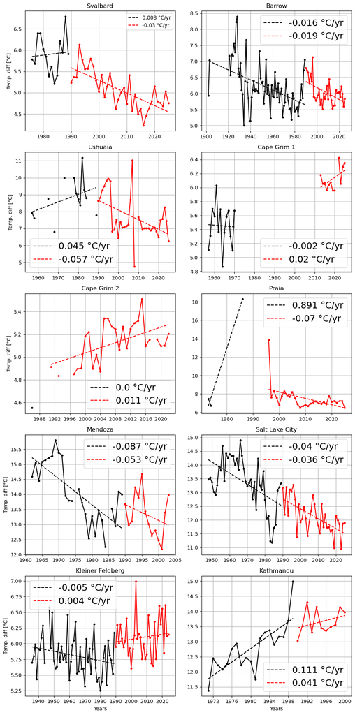

```python
fig, ax = plt.subplots(5, 2, figsize=(10, 20))

# Stations in the same order as your subplots
stations = [
    ('svalbard_DIFF_C', 'Svalbard'),
    ('barrow_DIFF_C', 'Barrow'),
    ('ushuaia_DIFF_C', 'Ushuaia'),
    ('cape_grim_1_DIFF_C', 'Cape Grim 1'),
    ('cape_grim_2_DIFF_C', 'Cape Grim 2'),
    ('praia_DIFF_C', 'Praia'),
    ('mendoza_DIFF_C', 'Mendoza'),
    ('salt_lake_city_DIFF_C', 'Salt Lake City'),
    ('kleiner_feldberg_DIFF_C', 'Kleiner Feldberg'),
    ('kathmandu_DIFF_C', 'Kathmandu'),
]

# Loop through grid positions
for (colname, title), axis in zip(stations, ax.flatten()):
    model_before, y_pred_before = get_trend_line(colname, ann_stations_merged_df_before_1990)
    model_after, y_pred_after = get_trend_line(colname, ann_stations_merged_df_after_1990)

    axis.plot(ann_stations_merged_df_before_1990[colname], '.-', color='black')
    axis.plot(ann_stations_merged_df_after_1990[colname], '.-', color='red')

    axis.plot(y_pred_before, '--', color='black', label='{} °C/yr'.format(model_before.coef_[0].round(3)))
    axis.plot(y_pred_after, '--', color='red',label='{} °C/yr'.format(model_after.coef_[0].round(3)))
    axis.set_title(title)
    axis.legend(fontsize=18)
    axis.grid()

# only legend for dirst one
ax[0,0].legend()
# Add shared Y-labels where needed
ax[0,0].set_ylabel('Temp. diff [°C]')
ax[1,0].set_ylabel('Temp. diff [°C]')
ax[2,0].set_ylabel('Temp. diff [°C]')
ax[3,0].set_ylabel('Temp. diff [°C]')
ax[4,0].set_ylabel('Temp. diff [°C]')

# X-labels for bottom row
# ax[1,0].set_xlabel('Years')
# ax[1,1].set_xlabel('Years')
# ax[1,2].set_xlabel('Years')
# ax[1,3].set_xlabel('Years')
# ax[1,4].set_xlabel('Years')
ax[4,0].set_xlabel('Years')
ax[4,1].set_xlabel('Years')

fig.tight_layout()
```

Annual trends from the stations:

[output not shown]

We can compare the derived trends wwith results from Zong et al. (2023). They used two station based datasets, which were gridded and gap-filled ove the land masses. The Climate Research Unit Time-Series version 4.07 (CRU) and Berkley Earth Surface Temperatures (BEST):

[figure not shown]

Further, they include the spatial distribution of the trend in diurnal temperature range (DTR) in Global Surface Summary of the Day (GSOD) during **1991–2020**:

[figure not shown]

## Trend analysis of the DTR shows partial agreement with previous publications.

Tne stations were analyzed regarding their diurnal temperature range (DTR), both by season and annual mean. Station maximum und an minimum temperatures were used from [Global Historical Climatology Network daily (GHCNd)](https://www.ncei.noaa.gov/products/land-based-station/global-historical-climatology-network-daily#:~:text=The%20Global%20Historical%20Climatology%20Network,suite%20of%20quality%20assurance%20reviews.).

The trend analysis separated by season showed that trends vary from station to station and that the trend may change significantly or even reverse over the course of the season. For example, the Svalbard station showed the strongest negative trend during the northern hemisphere (NH) winter, and the stations at Cape Grim showed the strongest positive trends during the southern hemisphere (SH) summer. At the Kleiner Feldberg station, the trend reverses over the course of the year, with a negative trend in winter and a positive trend in the other seasons. The NH high latitude stations show overall negative trends, whereas the SH high latitude stations do not show a clear picture. Caution is advised, as the trend is partly based on fewer observations due to periods with missing observations or short recording periods. Individual outliers can therefore have a strong influence on the trend, which is particularly evident at the Ushuaia and Praia stations.

For the annual trends, only years with less than 60 days of missing data are used with the exception for Ushuaia and Praia, as these stations show substantial less data and would not show annual records. By follwing the separation by Zhong et al. (2023) the time series are split into two time periods, before and after 1990 and two seperate trends were derived for each station. It is evident that dividing the time series is useful and that at some stations the trend changes significantly or reverses. It is also evident from the stations that most show a negative trend after 1990, which would generally contradict the findings of Liu et al. (2924) and Zhong et al. (2023) with a general shift from a negative to a positive trend. However, if one compares the station data with spatial distribution of trend in DTR in Global Surface Summary of the Day (GSOD) during 1991-2020 (presented in Zhong et al. 2023), a general agreement was observed with regard to the trends.

Literature:

Karl, Thomas R.; Jones, Philip D., Knight, Richard W., Kukla, George, Plummer, Neil, Razuvayev, Vyacheslav, Gallo, Kevin P ., Lindseay, Janette, Charlson, Robert J., and Peterson, Thomas C., Asymmetric Trends of Daily Maximum and Minimum Temperature . Papers in Natural Resources (1993). 185.https://digitalcommons.unl.edu/natrespapers/185

Liu, G., Guo, Y., Xia, H., Liu, X., Song, H., Yang, J., & Zhang, Y. Increase asymmetric warming rates between daytime and nighttime temperatures over global land during recent decades. Geophysical Research Letters, 51, e2024GL112832 (2024). https://doi.org/10.1029/2024GL112832

Zhong, Z., He, B., Chen, H.W. et al. Reversed asymmetric warming of sub-diurnal temperature over land during recent decades. Nat Commun 14, 7189 (2023). https://doi.org/10.1038/s41467-023-43007-6